# Plots for simulation with site effects

:)

2023-12-08

## Final analysis report

### Bias, Coverage, MSE

#### Scenario 4.2 Site difference > treatment difference

Different treatment effects in 8 sites compares to the other 2 sites: TAq = 30%, TBq = 35% TCq = 40% TDq = 45%, q = 3, …, 10; and TAq = 20%, TBq = 25%, TCq = 30%, TDq = 35%, q = 1, 2

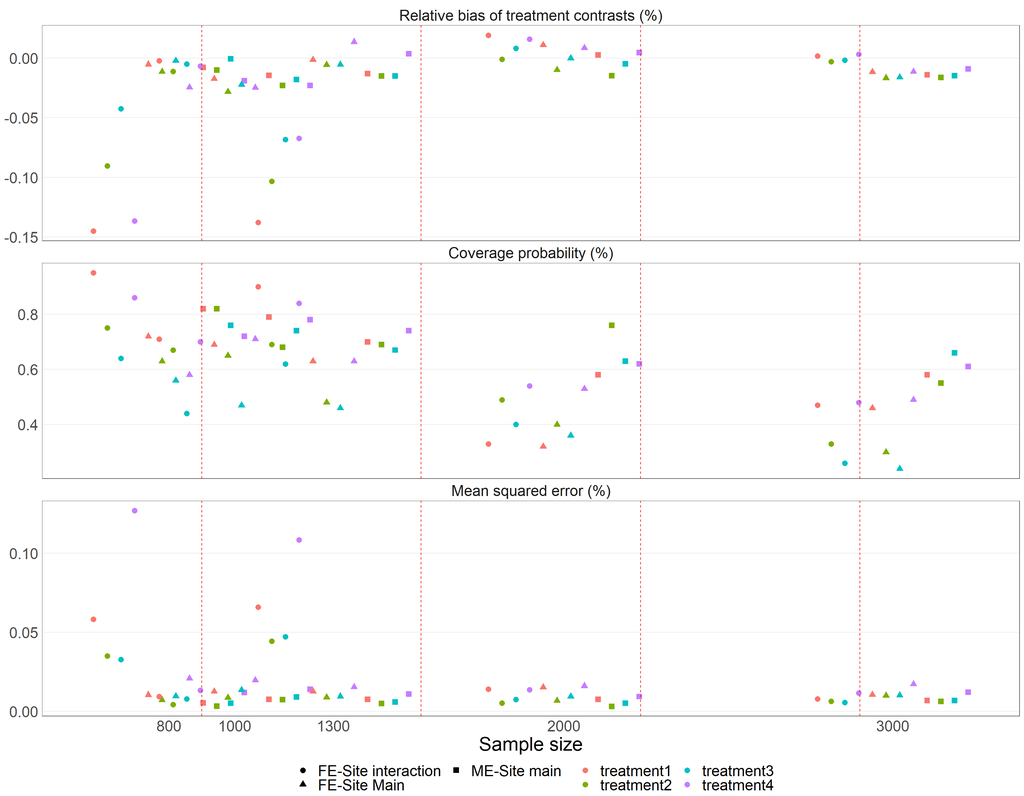

#### Scenario 4.2 Site difference < treatment difference

Different treatment effects in 8 sites compares to the other 2 sites: TAq = 30%, TBq = 35% TCq = 40% TDq = 45%, q = 3, …, 10; and TAq = 27.5%, TBq = 32.5%, TCq = 38.5%, TDq = 42.5%, q = 1, 2

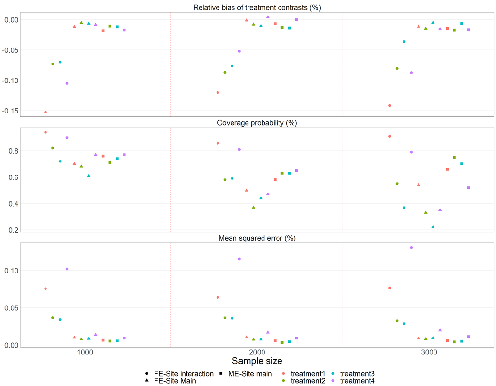

#### Scenario 1.3 initial seed

All 4 treatments have different effects (small difference): $T_A = 30\%$; $T_B = 35\%$; $T_C = 40\%$; $T_D = 45\%$

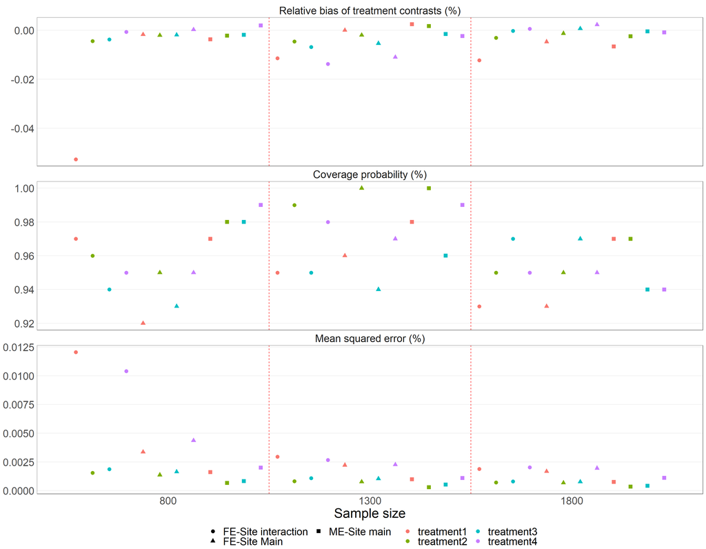

### Mortality gain

#### Scenario 4.2 Site difference > treatment difference

Different treatment effects in 8 sites compares to the other 2 sites: TAq = 30%, TBq = 35% TCq = 40% TDq = 45%, q = 3, …, 10; and TAq = 20%, TBq = 25%, TCq = 30%, TDq = 35%, q = 1, 2

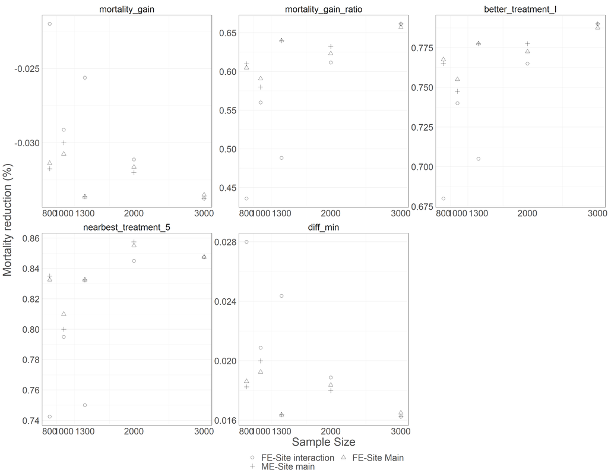

#### Scenario 4.2 Site difference < treatment difference

Different treatment effects in 8 sites compares to the other 2 sites: TAq = 30%, TBq = 35% TCq = 40% TDq = 45%, q = 3, …, 10; and TAq = 27.5%, TBq = 32.5%, TCq = 38.5%, TDq = 42.5%, q = 1, 2

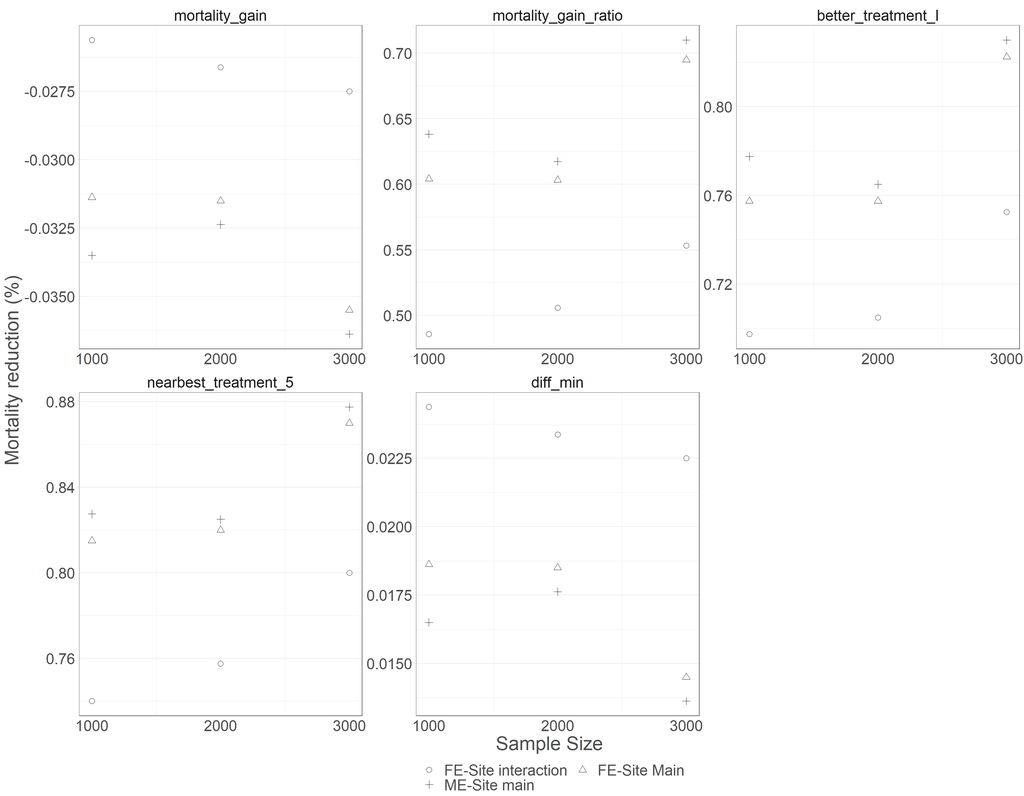

#### Scenario 1.3 initial seed

All 4 treatments have different effects (small difference): $T_A = 30\%$; $T_B = 35\%$; $T_C = 40\%$; $T_D = 45\%$

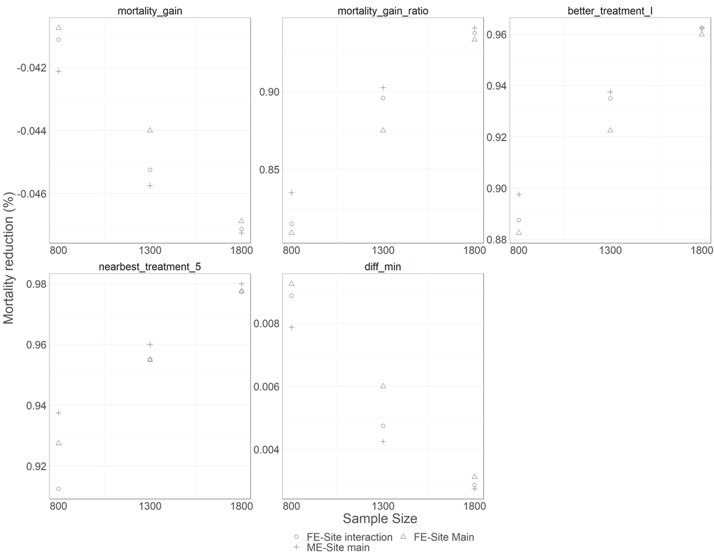